# A4: Prison Data

Manav Agarwal

2022-11-21

## Abstract

The assignment deals with prison data in the US from 1970-2018. As part of the instructions, I dealt with work that needed me to plot crime and imprisonment trends over the specified time frame. I also had to do the same, however, over specific state data. Lastly, I worked specifically with data involving black populations and how they are minoritized in the criminal justice system and its dealings.

## Data Summary

Black population in jails in 2016: 245882;

Black jail percentage in 2016: 33.5%;

Black population average over recorded years: 164400.81

These data points give more information than meets the eye. It is astonishing the number of black people in jails as recently as 2016, and their percentage in jails. As noted in the codebook, there were quiet a lot of missing variables, the presence of which would change the results significantly. Hence, it is safe to assume that the situation at present is much worse than originally assumed. Black people are significantly oppressed in the criminal justice system and seeing the 33.5% percentage alone can leave one astonished.

## Section 3

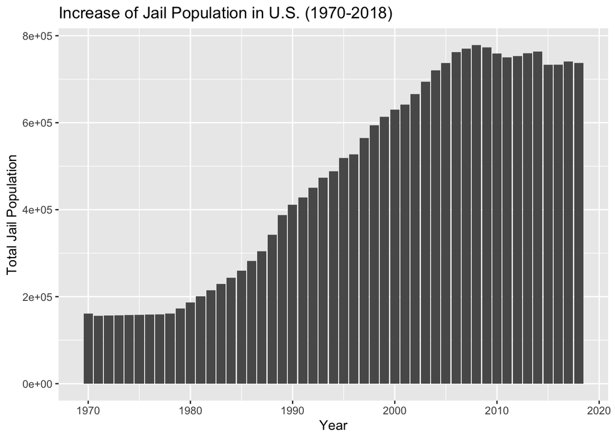

What is the trend of US Prison Population across the years recorded in the dataset?

As seen in this graph, the US prison population was mostly steady between 1970 and 1980, however, starting in the 80s, the prison population exploded and peaked in 2008. Following that, it has slowly decreased however there has not been considerable decrease in the numbers so far. This makes one question, what led to this sudden explosion in prison population starting in 1980?

## Section 4

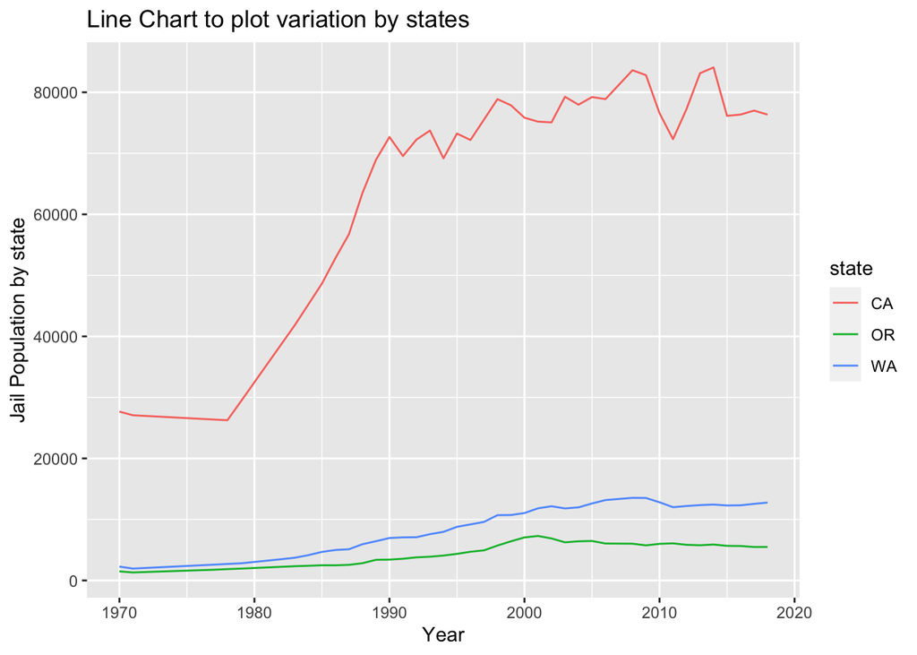

Where does the west coast stand on prison population?

As one could have imagined, California, the state with the largest population in the US has significantly higher jail populations as compared to the other two states. However, Washington and Oregon also have significant populations, while not nearly as much as California, but have managed to keep really low prison populations. This can make one wonder what are some policies that could have been undertaken by these two state governments that resulted in such a difference when compared to California?

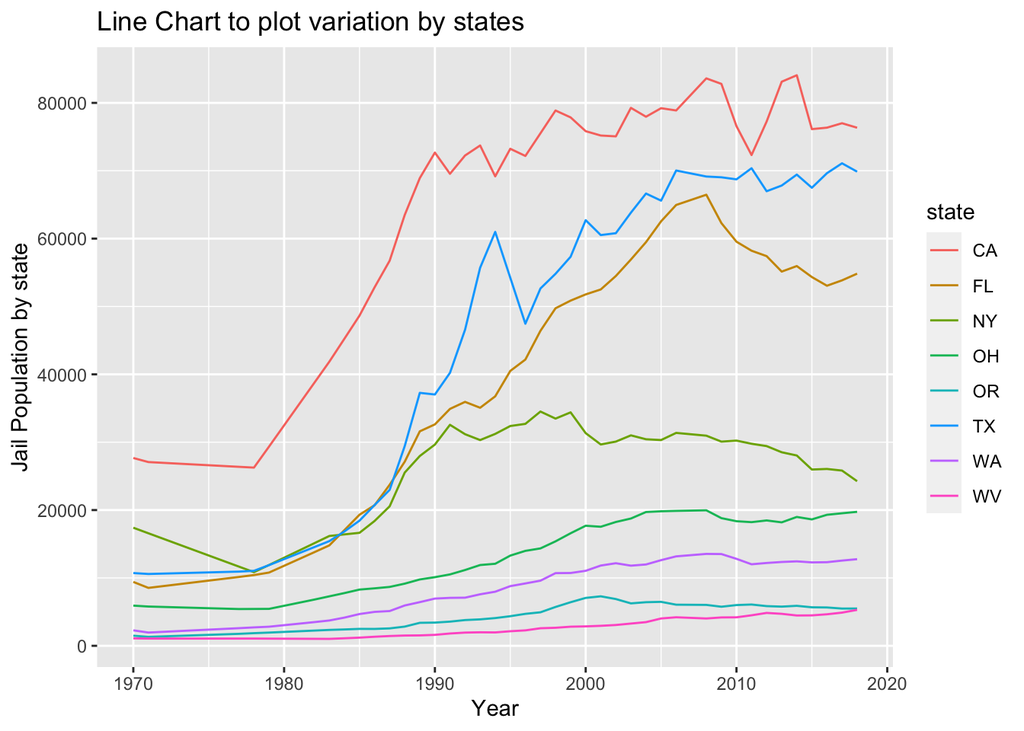

How do some of the states trend soecifically with Jail Population in their states?

While we already saw the results in the west coast states, adding some other states from various regions of the country shows new, interesting trends. New York has significantly lower populations for such an important and populous state. Furthermore, one can understand the numbers as seen for Texas and Florida.

## Section 5: Variable comparison that reveals potential patterns of inequality

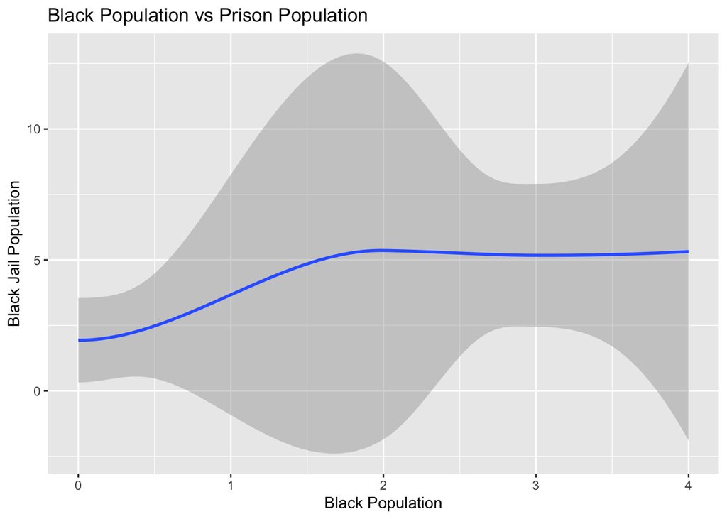

How do black populations map to the populations in jail?

## Section 6: A map shows potential patterns of inequality that vary geographically

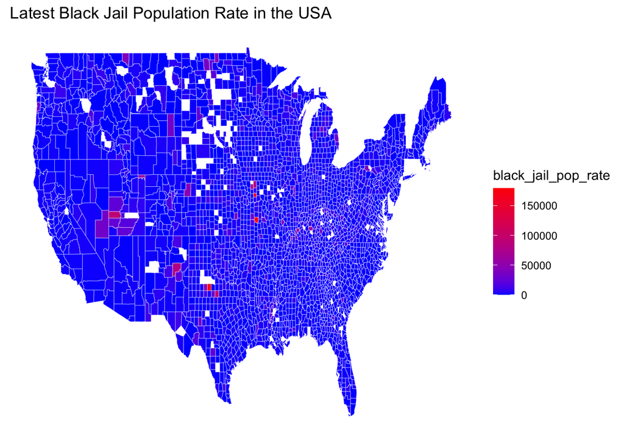

How do the jail rates among black populations trend on counties when plotted on a map?